# Regressão Logística e validação de suposições

```r
descritivo_perc(descr = descritivo2,ordem_colunas = c("variavel","cluster1","cluster3","cluster4","cluster2"),
                df_original = comorbidade_regressao_simples[-linhas_outlier,-c('puerpera_pre','cs_sexo_pre')],
                rotulos_clusters = influ_df2$cluster)
```

| variavel | cluster1 | cluster3 | cluster4 | cluster2 |
| --- | --- | --- | --- | --- |
| asma_pre_ignorado | 40.16 | 36.03 | 32.79 | 42.34 |
| asma_pre_não | 47.67 | 57.35 | 57.38 | 51.25 |
| asma_pre_sim | 12.17 | 6.62 | 9.84 | 6.42 |
| cardiopatia_pre_ignorado | 24.32 | 27.21 | 22.95 | 20.32 |
| cardiopatia_pre_não | 27.35 | 40.44 | 31.15 | 24.37 |
| cardiopatia_pre_sim | 48.32 | 32.35 | 45.90 | 55.31 |
| diabetes_pre_ignorado | 28.22 | 32.35 | 22.95 | 25.54 |
| diabetes_pre_não | 34.24 | 44.12 | 45.90 | 33.14 |
| diabetes_pre_sim | 37.53 | 23.53 | 31.15 | 41.32 |
| doenca_hematologica_pre_ignorado | 43.48 | 36.03 | 36.07 | 42.30 |

[output cut: 36 more lines]

É notável também que existe uma diferença muito aparente da sindrome de down nos clusters: ambos os que destoam dos demais estão sendo enviesados, de alguma forma, pela sindrome de down. Vejamos a remoção dela

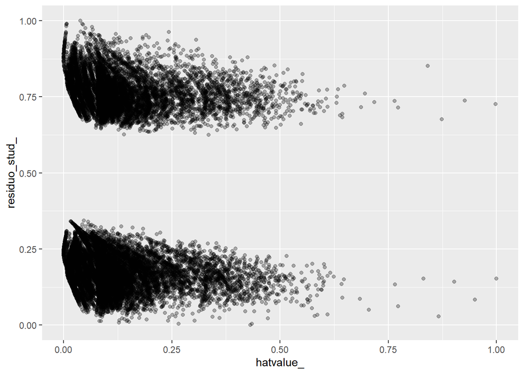

```r
# Agora sim, temos 2 nuvens bem parecidas
log_reg3 <- update(log_reg_sem_sexo,
                           formula = obito_pre ~ . - sindrome_de_down_pre,
                           subset = -linhas_outlier)
result <- grafico_influencia(log_reg3)
influ_df3 <- result$df_influencia

influ_df3[,`:=`(hatvalue_ = normalize(hatvalue),residuo_stud_ = normalize(residuo_stud))]
ggplot(influ_df3) + geom_point(aes(x = hatvalue_, y=residuo_stud_),alpha = 0.3)
```

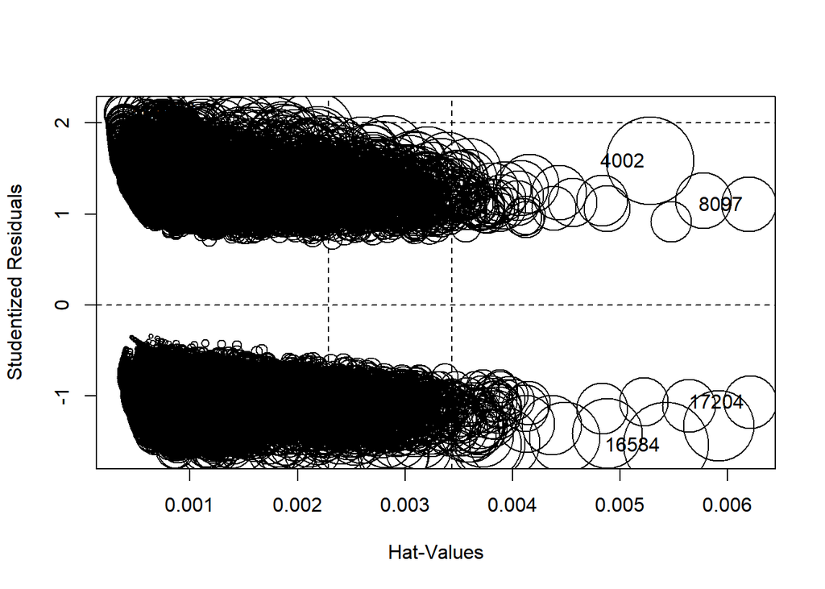

|  | StudRes | Hat | CookD |
| --- | --- | --- | --- |
| 4002 | 1.581796 | 0.0052806110 | 0.0005494990 |
| 4033 | 2.141965 | 0.0005899856 | 0.0002187643 |
| 4034 | 2.104993 | 0.0004036286 | 0.0001371914 |
| 8097 | 1.101634 | 0.0061969830 | 0.0002169433 |
| 16584 | -1.544737 | 0.0054252969 | 0.0005203314 |
| 17204 | -1.069929 | 0.0062078333 | 0.0002011985 |

```r
influencePlot(log_reg3)
```

Vejamos o que obtemos de resultado a partir do modelo 3

```r
#Tivemos uma segunda melhoria no modelo, removendo a sindrome de down
matriz_confusao(teste,log_reg3)
```

```
## Confusion Matrix and Statistics
##
##           Reference
## Prediction vivo morto
##      vivo  4045  2258
##      morto 1164  1519
##
##                Accuracy : 0.6192
##                  95% CI : (0.6091, 0.6292)
##     No Information Rate : 0.5797
##     P-Value [Acc > NIR] : 1.343e-14
##
##                   Kappa : 0.1861
##
##  Mcnemar's Test P-Value : < 2.2e-16
##
##             Sensitivity : 0.4022
##             Specificity : 0.7765
##          Pos Pred Value : 0.5662
##          Neg Pred Value : 0.6418
##               Precision : 0.5662
##                  Recall : 0.4022
##                      F1 : 0.4703
##              Prevalence : 0.4203
##          Detection Rate : 0.1690
##    Detection Prevalence : 0.2986
##       Balanced Accuracy : 0.5894
##
##        'Positive' Class : morto
##
```

```r
calcula_roc(df = teste,modelo = log_reg3)
```

```
## [1] "AUC =  0.65"
```

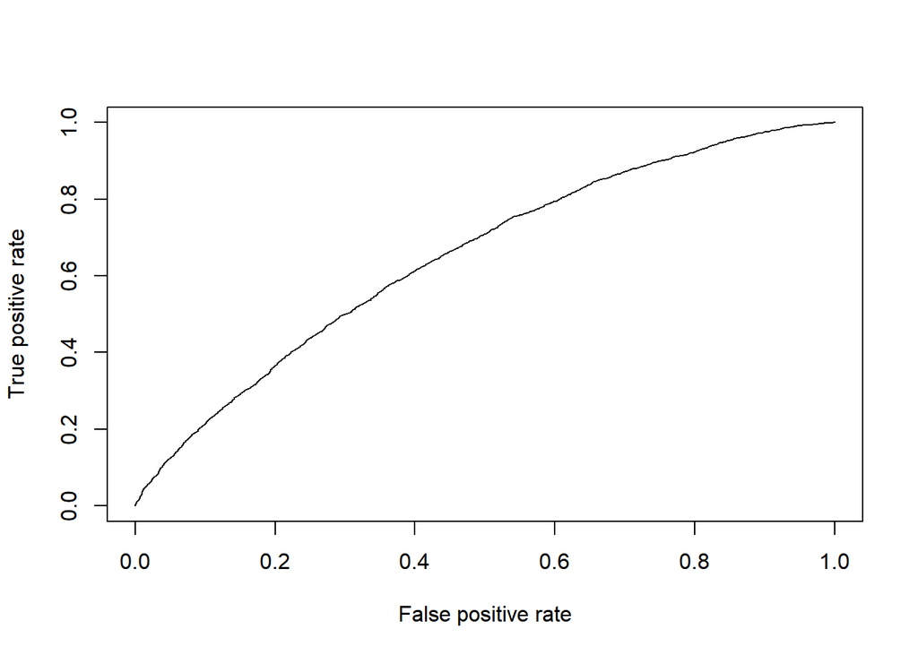

# Melhoria do modelo por meio da análise de resíduos

Pelo gráfico Binned, existem pontos que estão fora da margem de 95%, tanto para valores pequenos quanto para valores pequenos do predict quanto para valores grandes

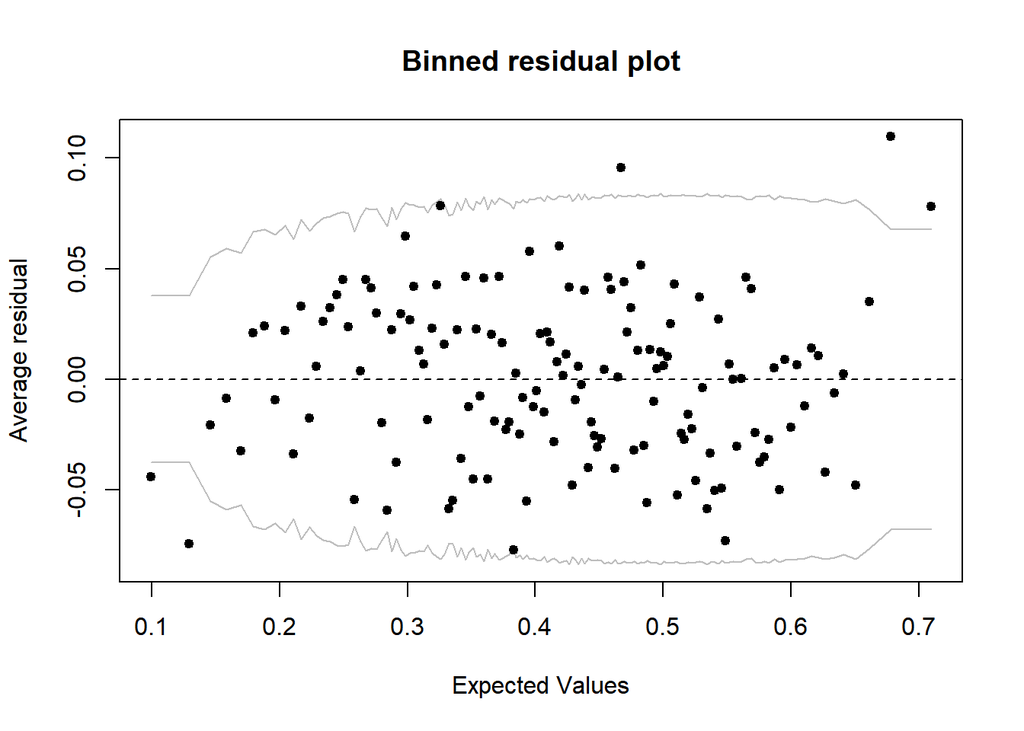

```r
arm::binnedplot(log_reg3$fitted.values,residuals(log_reg3,type = "response"))
```

Vemos que ainda os resíduos parecem ter alguma relação com a idade. Vamos tentar transformar a idade

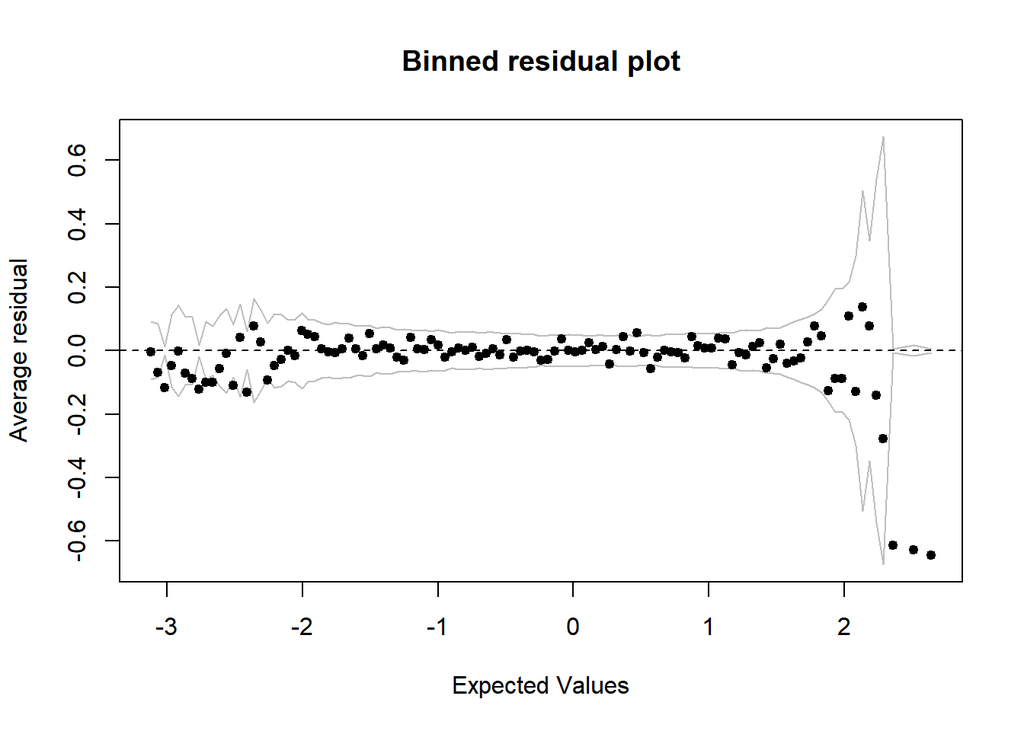

```r
arm::binnedplot(comorbidade_regressao_simples[-linhas_outlier]$idade_pre,residuals(log_reg3,type = "response"),nclass = 10000)
```

```r
#Criando um step
preparacao_log <- function(x){
  map(.x = x, ~ list(min = min(x)))
}


transformacao_log <- function(x,prep_output){
  dados <- select(x, names(prep_output))
  lista_resultado <- map2(.x = dados,.y = prep_output, .f = ~ log(.x - .y$min+0.01)  )
  names(lista_resultado) <- "idade_log"
  return(lista_resultado)
}

pipeline2 <- pipeline %>%
              step_custom_transformation(idade_pre,
                                         prep_function = preparacao_log,
                                         bake_function = transformacao_log,
                                         bake_how = "bind_cols")

log_reg4 <- update(log_reg3,
                   formula = update.formula(log_reg3$formula, . ~ . -idade_pre + idade_log),
                   data =pipeline2%>%prep()%>%bake(comorbidade_regressao_simples_total))
summary(log_reg4)
```

```
##
## Call:
## glm(formula = obito_pre ~ asma_pre + cardiopatia_pre + diabetes_pre +
##     doenca_hematologica_pre + doenca_hepatica_pre + doenca_neurologica_pre +
##     doenca_renal_pre + imunodepressao_pre + obesidade_pre + outros_fatores_de_risco_pre +
##     pneumopatia_pre + idade_log, family = binomial(link = "logit"),
##     data = pipeline2 %>% prep() %>% bake(comorbidade_regressao_simples_total),
##     subset = -linhas_outlier, x = T)
##
## Deviance Residuals:
##    Min      1Q  Median      3Q     Max
## -1.574  -1.059  -0.761   1.188   3.672
##
## Coefficients:
##                                  Estimate Std. Error z value Pr(>|z|)
## (Intercept)                    -1.7821732  0.0516640 -34.495  < 2e-16 ***
## asma_prenão                    -0.1978426  0.0589034  -3.359 0.000783 ***
## asma_presim                    -0.6086205  0.0557857 -10.910  < 2e-16 ***
## cardiopatia_prenão              0.0446022  0.0480240   0.929 0.353020
## cardiopatia_presim              0.1027874  0.0370990   2.771 0.005595 **
## diabetes_prenão                 0.0008402  0.0469030   0.018 0.985708
## diabetes_presim                 0.0507611  0.0368633   1.377 0.168509
## doenca_hematologica_prenão      0.0485799  0.0763487   0.636 0.524587
## doenca_hematologica_presim      0.0802920  0.0762482   1.053 0.292325
## doenca_hepatica_prenão          0.3307006  0.0728674   4.538 5.67e-06 ***
## doenca_hepatica_presim          0.4037435  0.0731889   5.516 3.46e-08 ***
## doenca_neurologica_prenão      -0.1339364  0.0557328  -2.403 0.016253 *
## doenca_neurologica_presim       0.1569947  0.0477262   3.289 0.001004 **
## doenca_renal_prenão            -0.1379306  0.0504023  -2.737 0.006208 **
## doenca_renal_presim             0.1127137  0.0428828   2.628 0.008578 **
## imunodepressao_prenão          -0.2093674  0.0567489  -3.689 0.000225 ***
## imunodepressao_presim          -0.1616502  0.0474457  -3.407 0.000657 ***
## obesidade_prenão                0.2601078  0.0428122   6.076 1.24e-09 ***
## obesidade_presim                0.3175845  0.0403621   7.868 3.59e-15 ***
## outros_fatores_de_risco_prenão  0.1295648  0.0375344   3.452 0.000557 ***
## outros_fatores_de_risco_presim  0.3403299  0.0295508  11.517  < 2e-16 ***
## pneumopatia_prenão             -0.0362726  0.0571447  -0.635 0.525591
## pneumopatia_presim              0.1348729  0.0476953   2.828 0.004687 **
## idade_log                       1.0768289  0.0374178  28.779  < 2e-16 ***
## ---
## Signif. codes:  0 '***' 0.001 '**' 0.01 '*' 0.05 '.' 0.1 ' ' 1
##
## (Dispersion parameter for binomial family taken to be 1)
##
##     Null deviance: 40743  on 29952  degrees of freedom
## Residual deviance: 38703  on 29929  degrees of freedom
## AIC: 38751
##
## Number of Fisher Scoring iterations: 4
```

Houve uma piora

```r
matriz_confusao(pipeline2%>%
                  prep()%>%
                  bake(comorbidade_regressao_simples_teste),
                log_reg4)
```

```
## Confusion Matrix and Statistics
##
##           Reference
## Prediction vivo morto
##      vivo  4118  2338
##      morto 1091  1439
##
##                Accuracy : 0.6184
##                  95% CI : (0.6083, 0.6285)
##     No Information Rate : 0.5797
##     P-Value [Acc > NIR] : 4.278e-14
##
##                   Kappa : 0.1797
##
##  Mcnemar's Test P-Value : < 2.2e-16
##
##             Sensitivity : 0.3810
##             Specificity : 0.7906
##          Pos Pred Value : 0.5688
##          Neg Pred Value : 0.6379
##               Precision : 0.5688
##                  Recall : 0.3810
##                      F1 : 0.4563
##              Prevalence : 0.4203
##          Detection Rate : 0.1601
##    Detection Prevalence : 0.2815
##       Balanced Accuracy : 0.5858
##
##        'Positive' Class : morto
##
```

```r
calcula_roc(df = pipeline2%>%
                                    prep()%>%
                                    bake(comorbidade_regressao_simples_teste),
                              modelo = log_reg4)
```

```
## [1] "AUC =  0.65"
```

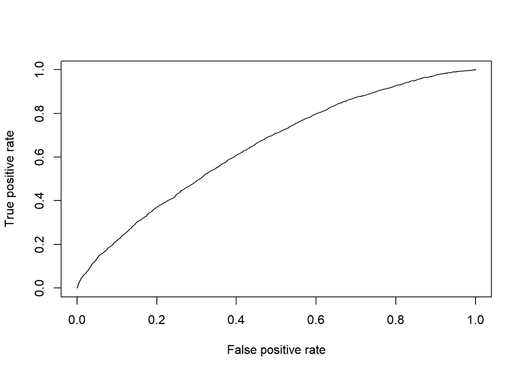

```r
transformacao_positiva <- function(x,prep_output){
                                                  dados <- select(x, names(prep_output))
                                                  map2(.x = dados,.y = prep_output, ~ .x - .y$min+0.01)
}



pipeline3 <- pipeline %>% step_custom_transformation("idade_pre",
                                                     prep_function = preparacao_log,
                                                     bake_function = transformacao_positiva,
                                                     bake_how = "replace") %>%
                            step_BoxCox("idade_pre")

log_reg5 <- update(log_reg3,
                   data =pipeline3%>%prep()%>%bake(comorbidade_regressao_simples_total))
summary(log_reg5)
```

```
##
## Call:
## glm(formula = obito_pre ~ asma_pre + cardiopatia_pre + diabetes_pre +
##     doenca_hematologica_pre + doenca_hepatica_pre + doenca_neurologica_pre +
##     doenca_renal_pre + imunodepressao_pre + obesidade_pre + outros_fatores_de_risco_pre +
##     pneumopatia_pre + idade_pre, family = binomial(link = "logit"),
##     data = pipeline3 %>% prep() %>% bake(comorbidade_regressao_simples_total),
##     subset = -linhas_outlier, x = T)
##
## Deviance Residuals:
##     Min       1Q   Median       3Q      Max
## -1.7121  -1.0329  -0.7429   1.1807   2.1177
##
## Coefficients:
##                                 Estimate Std. Error z value Pr(>|z|)
## (Intercept)                    -1.565045   0.042744 -36.615  < 2e-16 ***
## asma_prenão                    -0.189092   0.059201  -3.194 0.001403 **
## asma_presim                    -0.582855   0.056042 -10.400  < 2e-16 ***
## cardiopatia_prenão              0.050607   0.048232   1.049 0.294063
## cardiopatia_presim              0.097734   0.037240   2.624 0.008678 **
## diabetes_prenão                 0.006019   0.047167   0.128 0.898457
## diabetes_presim                 0.071893   0.037010   1.943 0.052072 .
## doenca_hematologica_prenão      0.057760   0.076653   0.754 0.451137
## doenca_hematologica_presim      0.091070   0.076490   1.191 0.233803
## doenca_hepatica_prenão          0.330511   0.073221   4.514 6.37e-06 ***
## doenca_hepatica_presim          0.447284   0.073436   6.091 1.12e-09 ***
## doenca_neurologica_prenão      -0.133268   0.056051  -2.378 0.017424 *
## doenca_neurologica_presim       0.105324   0.048117   2.189 0.028602 *
## doenca_renal_prenão            -0.139629   0.050675  -2.755 0.005862 **
## doenca_renal_presim             0.121491   0.043084   2.820 0.004804 **
## imunodepressao_prenão          -0.217635   0.056974  -3.820 0.000134 ***
## imunodepressao_presim          -0.137884   0.047592  -2.897 0.003765 **
## obesidade_prenão                0.255359   0.043075   5.928 3.06e-09 ***
## obesidade_presim                0.381602   0.040656   9.386  < 2e-16 ***
## outros_fatores_de_risco_prenão  0.137321   0.037720   3.641 0.000272 ***
## outros_fatores_de_risco_presim  0.346132   0.029674  11.665  < 2e-16 ***
## pneumopatia_prenão             -0.030802   0.057446  -0.536 0.591831
## pneumopatia_presim              0.127636   0.047937   2.663 0.007754 **
## idade_pre                       0.331207   0.009728  34.046  < 2e-16 ***
## ---
## Signif. codes:  0 '***' 0.001 '**' 0.01 '*' 0.05 '.' 0.1 ' ' 1
##
## (Dispersion parameter for binomial family taken to be 1)
##
##     Null deviance: 40743  on 29952  degrees of freedom
## Residual deviance: 38574  on 29929  degrees of freedom
## AIC: 38622
##
## Number of Fisher Scoring iterations: 4
```

O resultado com o processamento usando BoxCox é bem similar ao resultado sem fazer a alteração na variável idade

```r
matriz_confusao(pipeline3%>%
                  prep()%>%
                  bake(comorbidade_regressao_simples_teste),
                log_reg5)
```

```
## Confusion Matrix and Statistics
##
##           Reference
## Prediction vivo morto
##      vivo  4063  2278
##      morto 1146  1499
##
##                Accuracy : 0.619
##                  95% CI : (0.6088, 0.629)
##     No Information Rate : 0.5797
##     P-Value [Acc > NIR] : 1.875e-14
##
##                   Kappa : 0.1845
##
##  Mcnemar's Test P-Value : < 2.2e-16
##
##             Sensitivity : 0.3969
##             Specificity : 0.7800
##          Pos Pred Value : 0.5667
##          Neg Pred Value : 0.6408
##               Precision : 0.5667
##                  Recall : 0.3969
##                      F1 : 0.4668
##              Prevalence : 0.4203
##          Detection Rate : 0.1668
##    Detection Prevalence : 0.2943
##       Balanced Accuracy : 0.5884
##
##        'Positive' Class : morto
##
```

```r
calcula_roc(df = pipeline3%>%
                    prep()%>%
                    bake(comorbidade_regressao_simples_teste),
            modelo = log_reg5)
```

```
## [1] "AUC =  0.652"
```

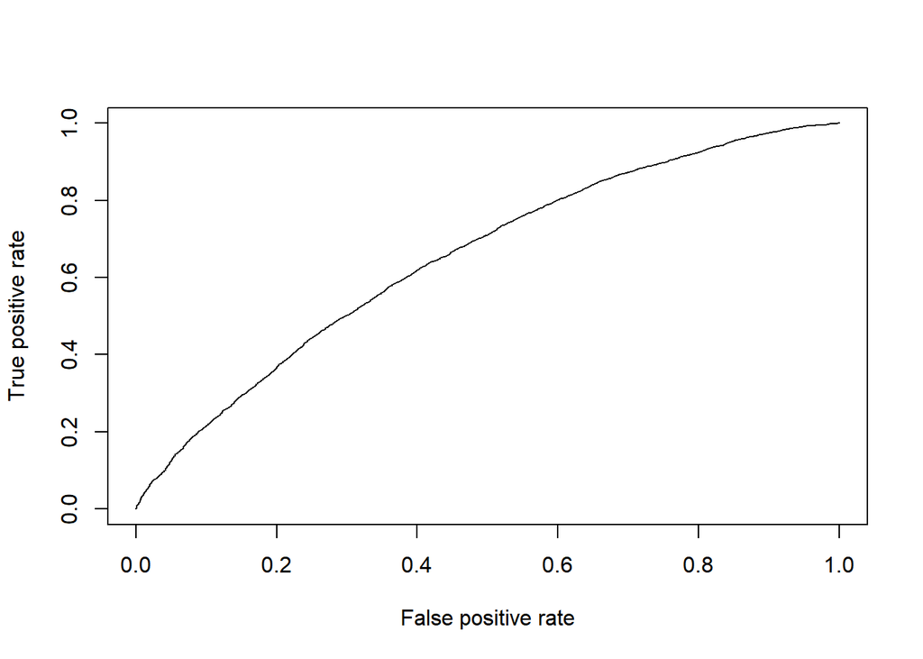

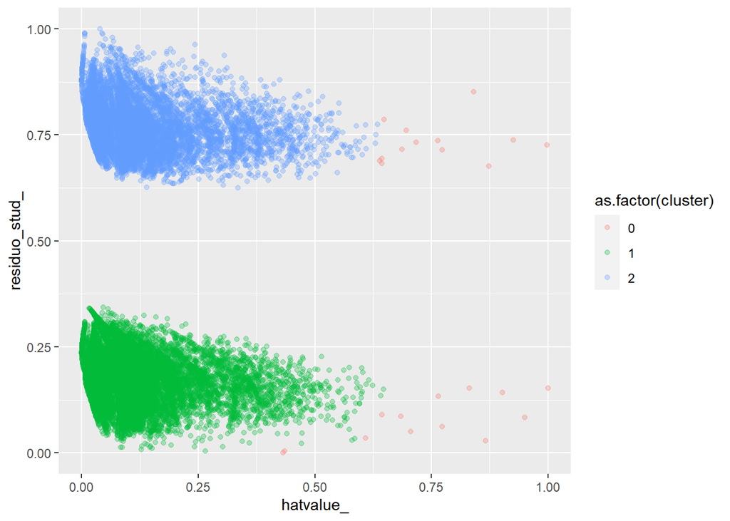

```r
db_result3 <- dbscan(x = as.matrix(influ_df3[,.(hatvalue_,residuo_stud_)]), eps = 0.0375)
influ_df3$cluster <- db_result3$cluster

ggplot(influ_df3) + geom_point(aes(x = hatvalue_, y=residuo_stud_,color = as.factor(cluster)),alpha = 0.3)
```

```r
descritivo_perc(describe_clusters(comorbidade_regressao_simples[-linhas_outlier],db_result3$cluster,modelo = log_reg3),
                df_original = comorbidade_regressao_simples[-linhas_outlier],rotulos_clusters = db_result3$cluster)
```

| variavel | cluster0 | cluster1 | cluster2 |
| --- | --- | --- | --- |
| cs_sexo_pre_feminino | 42.31 | 50.05 | 46.64 |
| cs_sexo_pre_masculino | 57.69 | 49.95 | 53.36 |
| asma_pre_ignorado | 26.92 | 40.10 | 42.27 |
| asma_pre_não | 19.23 | 47.79 | 51.28 |
| asma_pre_sim | 53.85 | 12.11 | 6.45 |
| cardiopatia_pre_ignorado | 3.85 | 24.35 | 20.38 |
| cardiopatia_pre_não | 19.23 | 27.51 | 24.41 |
| cardiopatia_pre_sim | 76.92 | 48.13 | 55.21 |
| diabetes_pre_ignorado | 7.69 | 28.28 | 25.55 |
| diabetes_pre_não | 11.54 | 34.36 | 33.24 |

[output cut: 41 more lines]

Vamos desconsiderar esses pontos influentes do treinamento

```r
log_reg6 <- update(log_reg,
                   formula = obito_pre ~ . -cs_sexo_pre - puerpera_pre - sindrome_de_down_pre,
                   data = comorbidade_regressao_simples[-linhas_outlier][-which(db_result3$cluster==0)])
summary(log_reg6)
```

```
##
## Call:
## glm(formula = obito_pre ~ asma_pre + cardiopatia_pre + diabetes_pre +
##     doenca_hematologica_pre + doenca_hepatica_pre + doenca_neurologica_pre +
##     doenca_renal_pre + imunodepressao_pre + obesidade_pre + outros_fatores_de_risco_pre +
##     pneumopatia_pre + idade_pre, family = binomial(link = "logit"),
##     data = comorbidade_regressao_simples[-linhas_outlier][-which(db_result3$cluster ==
##         0)], x = T)
##
## Deviance Residuals:
##     Min       1Q   Median       3Q      Max
## -1.6383  -1.0395  -0.7372   1.1794   2.1401
##
## Coefficients:
##                                 Estimate Std. Error z value Pr(>|z|)
## (Intercept)                    -0.648208   0.042437 -15.275  < 2e-16 ***
## asma_prenão                    -0.172062   0.071837  -2.395 0.016612 *
## asma_presim                    -0.622445   0.068246  -9.121  < 2e-16 ***
## cardiopatia_prenão              0.036101   0.057718   0.625 0.531659
## cardiopatia_presim              0.094294   0.044287   2.129 0.033242 *
## diabetes_prenão                -0.002477   0.056485  -0.044 0.965016
## diabetes_presim                 0.045420   0.044130   1.029 0.303370
## doenca_hematologica_prenão      0.150312   0.092395   1.627 0.103769
## doenca_hematologica_presim      0.141892   0.093307   1.521 0.128333
## doenca_hepatica_prenão          0.301861   0.087501   3.450 0.000561 ***
## doenca_hepatica_presim          0.434735   0.086941   5.000 5.72e-07 ***
## doenca_neurologica_prenão      -0.205946   0.066714  -3.087 0.002022 **
## doenca_neurologica_presim       0.087923   0.057281   1.535 0.124799
## doenca_renal_prenão            -0.109263   0.060559  -1.804 0.071196 .
## doenca_renal_presim             0.103299   0.051521   2.005 0.044964 *
## imunodepressao_prenão          -0.212388   0.068174  -3.115 0.001837 **
## imunodepressao_presim          -0.121009   0.056947  -2.125 0.033592 *
## obesidade_prenão                0.264404   0.051573   5.127 2.95e-07 ***
## obesidade_presim                0.427487   0.048417   8.829  < 2e-16 ***
## outros_fatores_de_risco_prenão  0.173208   0.045149   3.836 0.000125 ***
## outros_fatores_de_risco_presim  0.352005   0.035379   9.950  < 2e-16 ***
## pneumopatia_prenão             -0.098084   0.069356  -1.414 0.157298
## pneumopatia_presim              0.101188   0.057571   1.758 0.078812 .
## idade_pre                       0.466444   0.016608  28.086  < 2e-16 ***
## ---
## Signif. codes:  0 '***' 0.001 '**' 0.01 '*' 0.05 '.' 0.1 ' ' 1
##
## (Dispersion parameter for binomial family taken to be 1)
##
##     Null deviance: 28479  on 20940  degrees of freedom
## Residual deviance: 26938  on 20917  degrees of freedom
## AIC: 26986
##
## Number of Fisher Scoring iterations: 4
```

Não obtivemos melhorias, mesmo removendo os pontos “outliers” do gráfico de influência acima

```r
matriz_confusao(teste,log_reg6)
```

```
## Confusion Matrix and Statistics
##
##           Reference
## Prediction vivo morto
##      vivo  4026  2254
##      morto 1183  1523
##
##                Accuracy : 0.6175
##                  95% CI : (0.6074, 0.6276)
##     No Information Rate : 0.5797
##     P-Value [Acc > NIR] : 1.564e-13
##
##                   Kappa : 0.1833
##
##  Mcnemar's Test P-Value : < 2.2e-16
##
##             Sensitivity : 0.4032
##             Specificity : 0.7729
##          Pos Pred Value : 0.5628
##          Neg Pred Value : 0.6411
##               Precision : 0.5628
##                  Recall : 0.4032
##                      F1 : 0.4698
##              Prevalence : 0.4203
##          Detection Rate : 0.1695
##    Detection Prevalence : 0.3011
##       Balanced Accuracy : 0.5881
##
##        'Positive' Class : morto
##
```

# Abordagem de múltiplos regressores

Pelo gráfico de resíduos em função da variável idade, vimos que não conseguimos melhorar os resultados. Portanto, vamos separar em grupos os dados, com base na idade, tendo dessa forma, grupos com idades mais próximas entre si. A esperança nesse caso é que pessoas com idades mais próximas sejam mais parecidas entre si de tal forma que um modelo linear possa realizar a separação das classes e explicar bem o comportamento do grupo

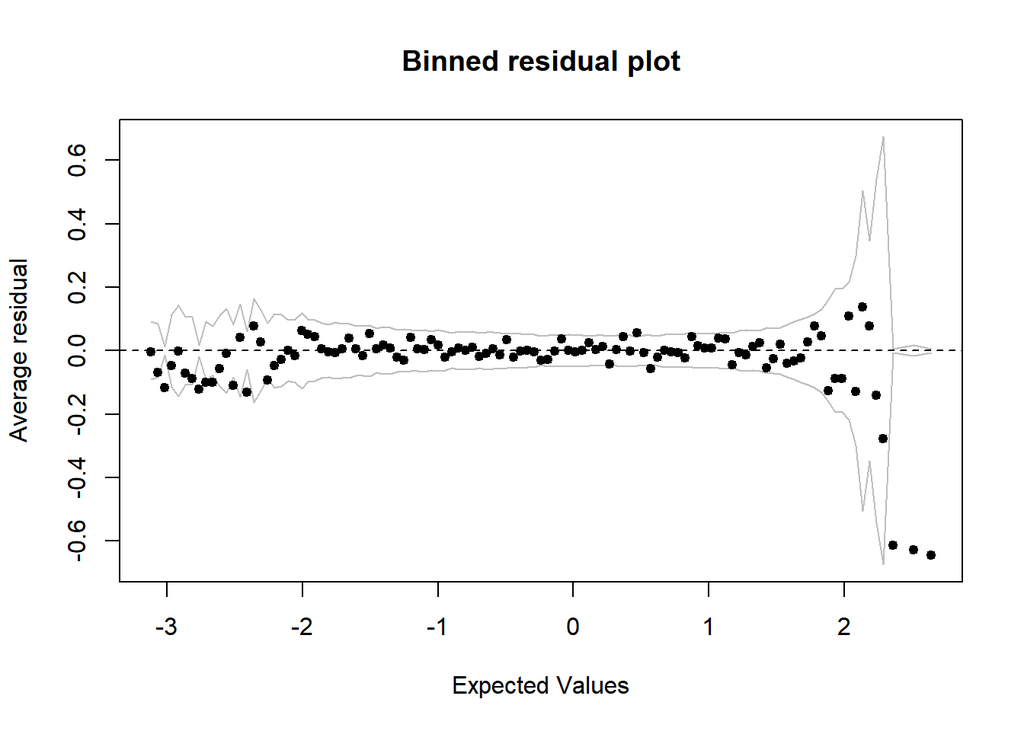

```r
arm::binnedplot(comorbidade_regressao_simples[-linhas_outlier]$idade_pre,
                                  residuals(log_reg3,type = "response"),
                                  nclass = 10000)
```

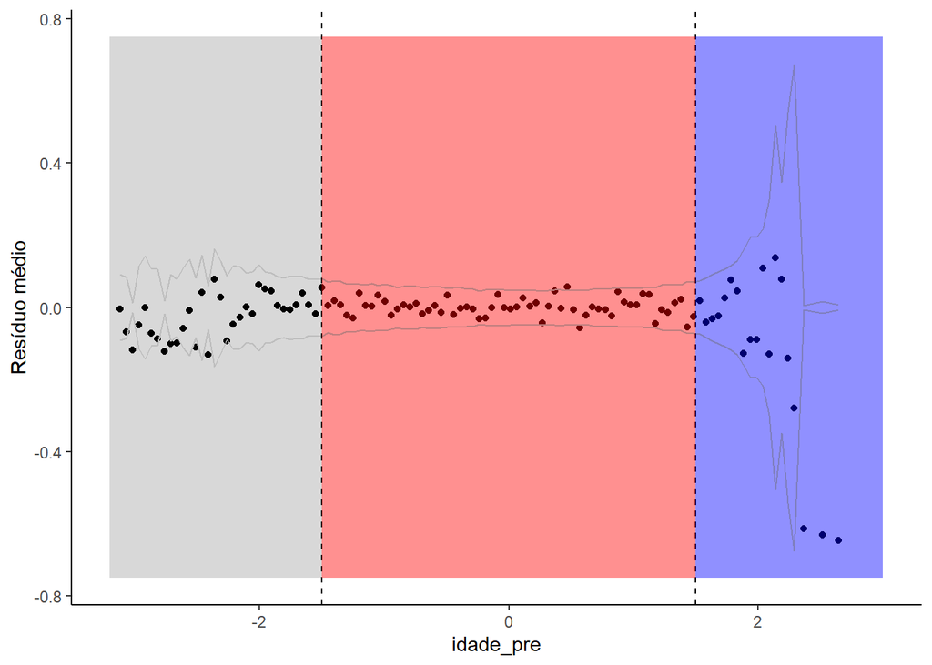

```r
lista_residuo_idade<-arm::binned.resids(comorbidade_regressao_simples[-linhas_outlier]$idade_pre,
                                  residuals(log_reg3,type = "response"),
                                  nclass = 10000)
df_residuo_idade <- as.data.frame(lista_residuo_idade$binned)
names(df_residuo_idade)[6] <- "se2"

ggplot(df_residuo_idade) + geom_point(aes(x = xbar,y=ybar)) +
      geom_line(aes_string(x = "xbar", y = "se2"),color="gray") +
      geom_line(aes_string(x = "xbar", y = "- se2"),color="gray") +
      xlab("idade_pre") + ylab("Resíduo médio") +
      geom_vline(aes(xintercept = -1.5),linetype = "dashed") +
      geom_vline(aes(xintercept = 1.5),linetype = "dashed")+
      geom_rect(aes(xmin = -3.2, xmax = -1.5,ymin = -0.75, ymax = 0.75),alpha=0.002) +
      geom_rect(aes(xmin = -1.5, xmax = 1.5,ymin = -0.75, ymax = 0.75),alpha=0.002,fill = "red") +
      geom_rect(aes(xmin = 1.5, xmax = 3,ymin = -0.75, ymax = 0.75),alpha=0.002,fill = "blue") +
      theme(panel.background = element_blank(),axis.line.x = element_line(),axis.line.y = element_line())
```

Vamos preparar as bases de treino

```r
limites_idade <- c(-1.5,1.5)
df_cinza = comorbidade_regressao_simples[-linhas_outlier][idade_pre < limites_idade[1]]
df_vermelho = comorbidade_regressao_simples[-linhas_outlier][idade_pre >= limites_idade[1] & idade_pre <= limites_idade[2]]
df_azul = comorbidade_regressao_simples[-linhas_outlier][idade_pre > limites_idade[2]]
```

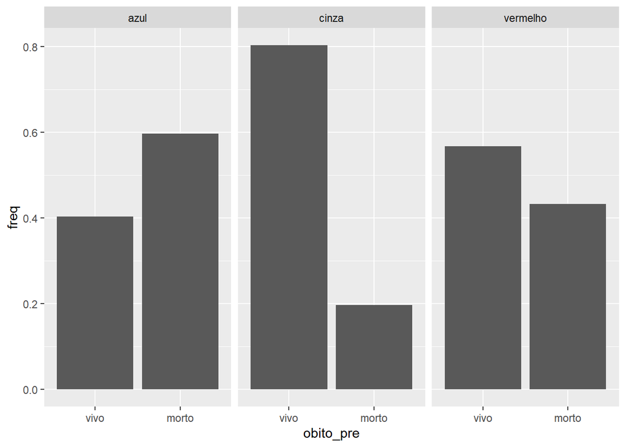

```r
ggplot(rbind(df_cinza%>%mutate(grupo = "cinza"),
      df_vermelho%>%mutate(grupo = "vermelho"),
      df_azul%>%mutate(grupo = "azul"))%>%group_by(grupo,obito_pre)%>%summarise(n=n())%>%mutate(freq = n / sum(n))) +
    geom_col(aes(x = obito_pre,y = freq)) +
    facet_wrap("grupo")
```

```r
log_reg_cinza <- update(log_reg3,data = df_cinza)
log_reg_vermelho <- update(log_reg3,data = df_vermelho)
log_reg_azul <- update(log_reg3,data = df_azul)
```

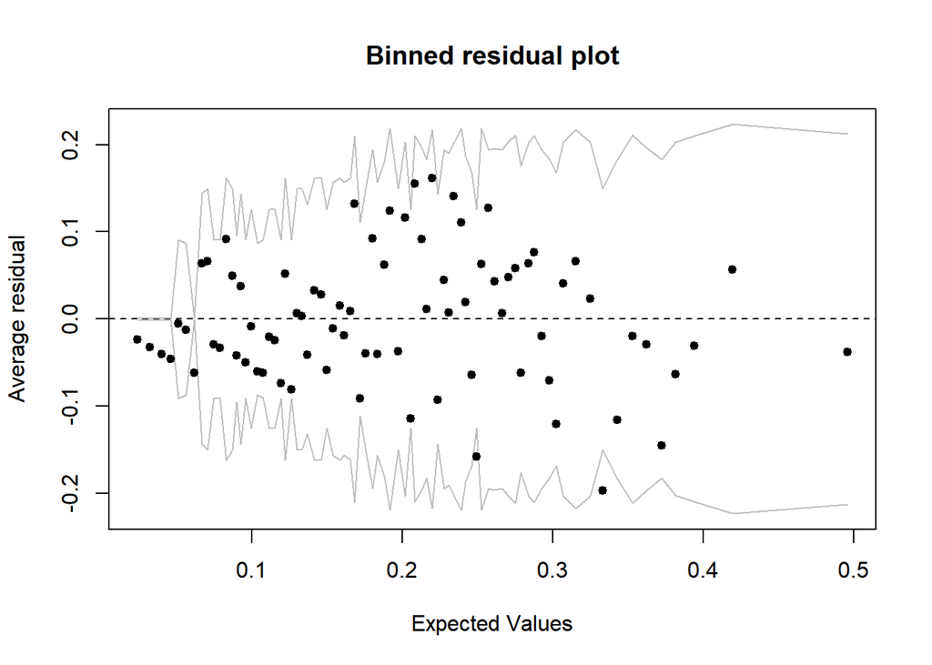

```r
arm::binnedplot(x=fitted(log_reg_cinza),y=residuals(log_reg_cinza,type = "response"),nclass = 80)
```

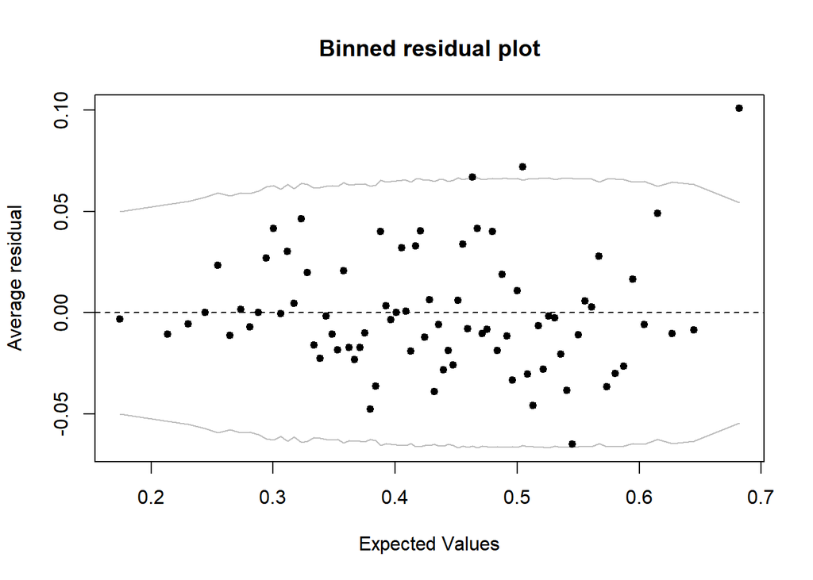

```r
arm::binnedplot(x=fitted(log_reg_vermelho),y=residuals(log_reg_vermelho,type = "response"),nclass = 80)
```

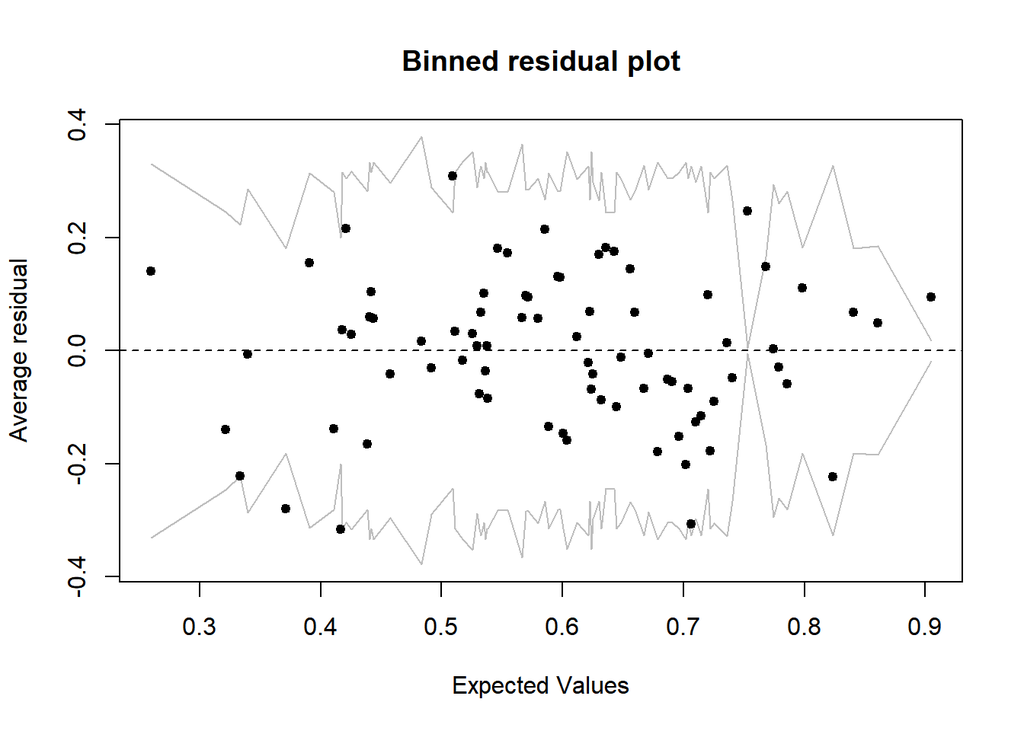

```r
arm::binnedplot(x=fitted(log_reg_azul),y=residuals(log_reg_azul,type = "response"),nclass = 80)
```

```r
matriz_confusao(pipeline%>%prep()%>%bake(comorbidade_regressao_simples_teste)%>%filter(idade_pre < limites_idade[1]),
                modelo = log_reg_cinza)
```

```
## Confusion Matrix and Statistics
##
##           Reference
## Prediction vivo morto
##      vivo   611   137
##      morto    4     3
##
##                Accuracy : 0.8132
##                  95% CI : (0.7836, 0.8404)
##     No Information Rate : 0.8146
##     P-Value [Acc > NIR] : 0.5596
##
##                   Kappa : 0.0236
##
##  Mcnemar's Test P-Value : <2e-16
##
##             Sensitivity : 0.021429
##             Specificity : 0.993496
##          Pos Pred Value : 0.428571
##          Neg Pred Value : 0.816845
##               Precision : 0.428571
##                  Recall : 0.021429
##                      F1 : 0.040816
##              Prevalence : 0.185430
##          Detection Rate : 0.003974
##    Detection Prevalence : 0.009272
##       Balanced Accuracy : 0.507462
##
##        'Positive' Class : morto
##
```

```r
calcula_roc(pipeline%>%prep()%>%bake(comorbidade_regressao_simples_teste)%>%filter(idade_pre < limites_idade[1]),
            modelo = log_reg_cinza)
```

```
## [1] "AUC =  0.639"
```

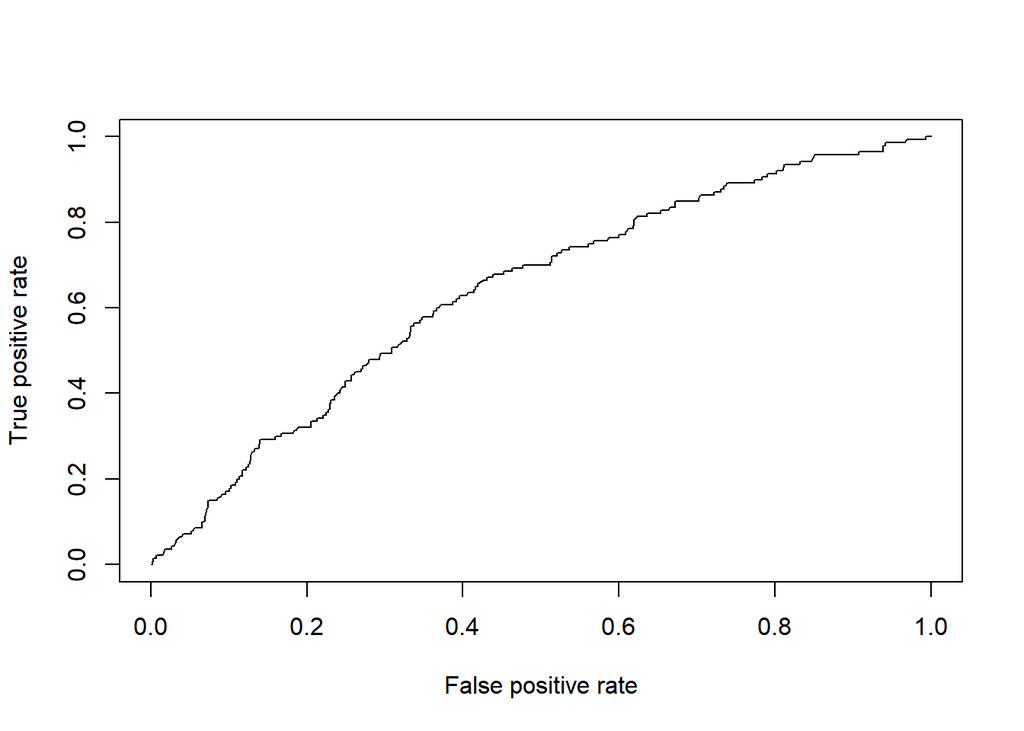

```r
matriz_confusao(pipeline%>%prep()%>%bake(comorbidade_regressao_simples_teste)%>%
                    filter(idade_pre >= limites_idade[1] & idade_pre <= limites_idade[2]),
                modelo = log_reg_vermelho)
```

```
## Confusion Matrix and Statistics
##
##           Reference
## Prediction vivo morto
##      vivo  3425  2113
##      morto 1013  1279
##
##                Accuracy : 0.6008
##                  95% CI : (0.5898, 0.6116)
##     No Information Rate : 0.5668
##     P-Value [Acc > NIR] : 6.171e-10
##
##                   Kappa : 0.1547
##
##  Mcnemar's Test P-Value : < 2.2e-16
##
##             Sensitivity : 0.3771
##             Specificity : 0.7717
##          Pos Pred Value : 0.5580
##          Neg Pred Value : 0.6185
##               Precision : 0.5580
##                  Recall : 0.3771
##                      F1 : 0.4500
##              Prevalence : 0.4332
##          Detection Rate : 0.1633
##    Detection Prevalence : 0.2927
##       Balanced Accuracy : 0.5744
##
##        'Positive' Class : morto
##
```

```r
calcula_roc(pipeline%>%prep()%>%bake(comorbidade_regressao_simples_teste)%>%
                    filter(idade_pre >= limites_idade[1] & idade_pre <= limites_idade[2]),modelo = log_reg_vermelho)
```

```
## [1] "AUC =  0.623"
```

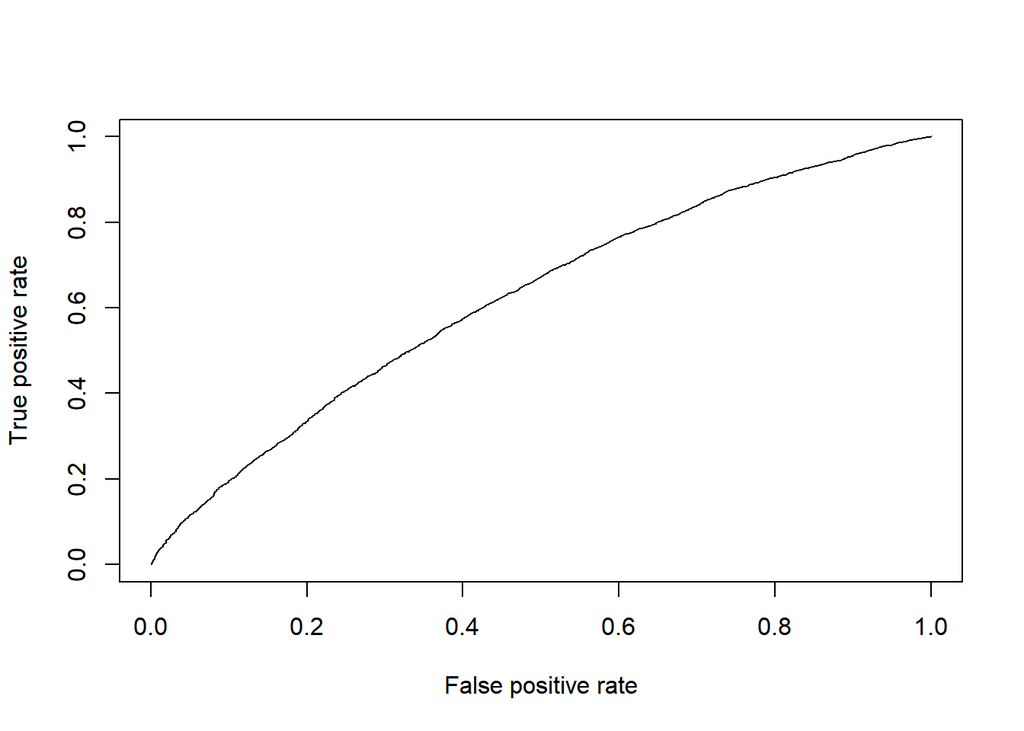

```r
matriz_confusao(pipeline%>%prep()%>%bake(comorbidade_regressao_simples_teste)%>%
                    filter(idade_pre > limites_idade[2]),
                modelo = log_reg_azul)
```

```
## Confusion Matrix and Statistics
##
##           Reference
## Prediction vivo morto
##      vivo    35    46
##      morto  121   199
##
##                Accuracy : 0.5835
##                  95% CI : (0.5336, 0.6323)
##     No Information Rate : 0.611
##     P-Value [Acc > NIR] : 0.8803
##
##                   Kappa : 0.0401
##
##  Mcnemar's Test P-Value : 1.026e-08
##
##             Sensitivity : 0.8122
##             Specificity : 0.2244
##          Pos Pred Value : 0.6219
##          Neg Pred Value : 0.4321
##               Precision : 0.6219
##                  Recall : 0.8122
##                      F1 : 0.7044
##              Prevalence : 0.6110
##          Detection Rate : 0.4963
##    Detection Prevalence : 0.7980
##       Balanced Accuracy : 0.5183
##
##        'Positive' Class : morto
##
```

```r
calcula_roc(pipeline%>%prep()%>%bake(comorbidade_regressao_simples_teste)%>%
                    filter(idade_pre > limites_idade[2]),modelo = log_reg_azul)
```

```
## [1] "AUC =  0.561"
```

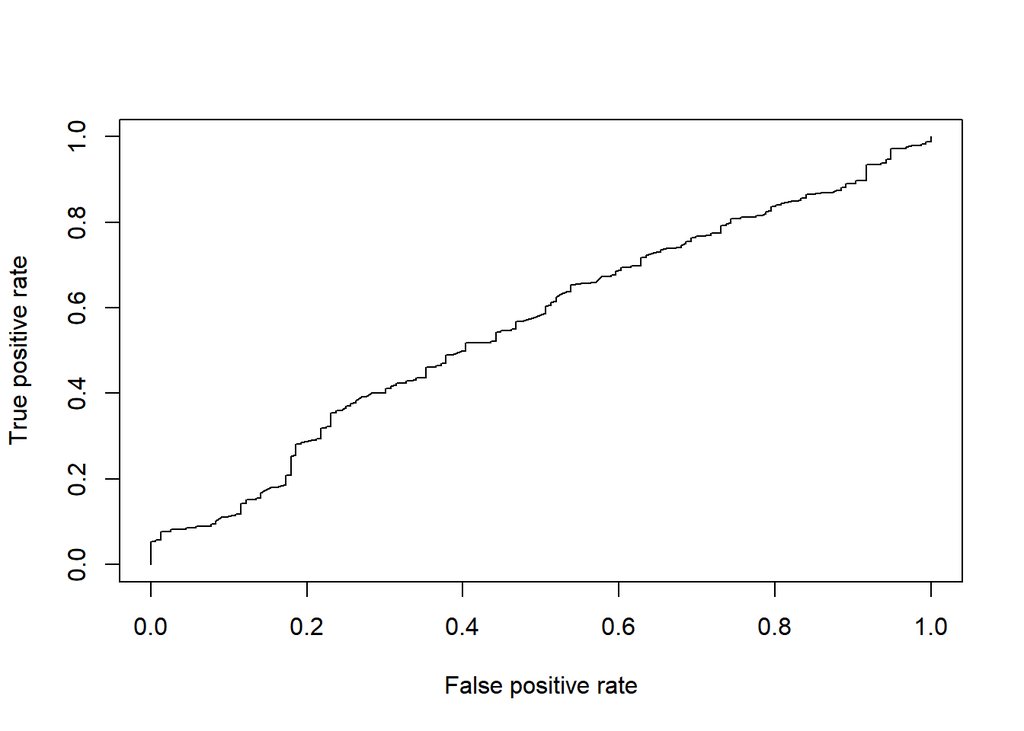

# Referências interessantes

https://bbolker.github.io/stat4c03/notes/logistic.pdf https://stats.stackexchange.com/questions/166585/pearson-vs-deviance-residuals-in-logistic-regression

# Coisas a fazer

Metricas para usar para avaliar a colianearidade entre as variaveis

‘klPQ’, ‘klQP’, ‘hellinger’, ‘jensen-shannon’ ‘bhattacharya’ pyAgrum

fscore curva ROC

ncd - complearn

separar os obito e nao obito e extratos de idades e fazer as matrizes de distancia